# Bellabeat CaseStudy

Naveed Narejo

2023-02-15

# Google Data Analytics Capstone: Bellabeat Case Study:

The Bellabeat Marketing Analysis is the second case study of Google’s Data Analytics Professional Certificate program. The case study requires the analyst to follow to the steps of the data analysis process (Ask, Prepare, Process, Analyze, Share, and Act) to analyze FitBit Fitness Tracker dataset.

## Step 1: Ask

### About the Company :

Bellabeat is a high-tech company that manufactures health-focused smart products. Sršen used her background as an artist to develop beautifully designed technology that informs and inspires women around the world. Collecting data on activity, sleep, stress, and reproductive health has allowed Bellabeat to empower women with knowledge about their own health and habits.

##### Key Stakeholders:

- Urška Sršen: Bellabeat’s co founder and Chief Creative Officer
- Sando Mur: Mathematician and Bellabeat’s co-founder
- Bellabeat marketing analytics team: A team of data analysts responsible for collecting, analyzing, and reporting data that helps guide Bellabeat’s marketing strategy

### Business Task:

Unlock new growth opportunities by analyzing smart device fitness data and gaining insight into how consumers use their smart devices, which will help guide he marketing strategy for the company.

##### Data analysis goal:

1. What are some trends in smart device usage?
2. How could these trends apply to Bellabeat customers?
3. How could these trends help influence Bellabeat marketing strategy?

### Deliverables:

- A clear summary of the business task
- A description of all data sources used
- Documentation of any cleaning or manipulation of data
- A summary of your analysis
- Supporting visualizations and key findings
- Your top high-level content recommendations based on your analysis

## Step 2: Prepare

### Installing R-Package

Installing the R-packages needed for the required analysis.

```r
  # install.packages("tidyverse")   #   Functions: dplyr(), tidyr() , stringr(), tibble(), readr(), purrr(), ggplot2() )
  # install.packages("janitor")     #   Functions: clean_names(), remove_empty(), get_dupes() )
  # install.packages("lubridate")   #   Functions: datetime fuctions
  # install.packages("plotly")      #   Functions: plot_ly()
  # install.packages("dplyr")       #   Functions: pipes()
  # install.packages("ggalluvial")  #   Functions: ggplot2 extension
  # install.packages("devtools")    #   Functions: load_all(), document(), test(), install_github()
  # devtools::install_github("kassambara/ggpubr") #   Functions: to break in quartiles in graphs
  # install.packages("gginnards")   #   Functions: ggplot2 extension for static and geometric analysis
  # install.packages("scales")      #   Functions: labeling as percents, dollars or scientific notation
```

## Loading R Environment

Loading the packages needed for the data processing and required analysis.

```r
  library(tidyverse)
  library(janitor)
  library(lubridate)
```

```r
  library(plotly)
  library(dplyr)
  library(ggalluvial)
  library(ggpubr)
  library(gghighlight)
  library(gginnards)
  library(scales)
```

## Step 3: Process

### Importing files

For this analysis we will be using these four datasets:

- dailyActivity_merged.csv
- sleepDay_merged.csv
- weightLogInfo_merged.csv
- hourlysteps_merged.csv

```r
 daily_activity <- read_csv(file = "D:\\Fitness Tracker CaseStudy\\Fitabase Data 4.12.16-5.12.16\\dailyActivity_merged.csv")%>%
 remove_empty()
```

```
## value for "which" not specified, defaulting to c("rows", "cols")
```

```r
 steps_perhour <- read_csv(file = "D:\\Fitness Tracker CaseStudy\\Fitabase Data 4.12.16-5.12.16\\hourlySteps_merged.csv")%>%
 remove_empty()
```

```
## value for "which" not specified, defaulting to c("rows", "cols")
```

```r
 sleep_data <- read_csv(file = "D:\\Fitness Tracker CaseStudy\\Fitabase Data 4.12.16-5.12.16\\sleepDay_merged.csv")%>%
 remove_empty()
```

```
## value for "which" not specified, defaulting to c("rows", "cols")
```

```r
  weight_data <- read_csv(file = "D:\\Fitness Tracker CaseStudy\\Fitabase Data 4.12.16-5.12.16\\weightLogInfo_merged.csv")%>%
 remove_empty()
```

```
## value for "which" not specified, defaulting to c("rows", "cols")
```

```r
     head(daily_activity) # 1st glimpse of the data
```

```
## # A tibble: 6 × 16
##         Id Activ…¹ Day   Total…² Total…³ Track…⁴ Logge…⁵ VeryA…⁶ Moder…⁷ Light…⁸
##      <dbl> <chr>   <chr>   <dbl>   <dbl>   <dbl>   <dbl>   <dbl>   <dbl>   <dbl>
## 1   1.50e9 4/12/2… Tues…   13162    8.5     8.5        0    1.88   0.550    6.06
## 2   1.50e9 4/13/2… Wedn…   10735    6.97    6.97       0    1.57   0.690    4.71
## 3   1.50e9 4/14/2… Thur…   10460    6.74    6.74       0    2.44   0.400    3.91
## 4   1.50e9 4/15/2… Frid…    9762    6.28    6.28       0    2.14   1.26     2.83
## 5   1.50e9 4/16/2… Satu…   12669    8.16    8.16       0    2.71   0.410    5.04
## 6   1.50e9 4/17/2… Sund…    9705    6.48    6.48       0    3.19   0.780    2.51
## # … with 6 more variables: SedentaryActiveDistance <dbl>,
## #   VeryActiveMinutes <dbl>, FairlyActiveMinutes <dbl>,
## #   LightlyActiveMinutes <dbl>, SedentaryMinutes <dbl>, Calories <dbl>, and
## #   abbreviated variable names ¹ActivityDate, ²TotalSteps, ³TotalDistance,
## #   ⁴TrackerDistance, ⁵LoggedActivitiesDistance, ⁶VeryActiveDistance,
## #   ⁷ModeratelyActiveDistance, ⁸LightActiveDistance
```

```r
     head(weight_data) # 1st glimpse of the data
```

```
## # A tibble: 6 × 8
##           Id Date                  WeightKg Weight…¹   Fat   BMI IsMan…²   LogId
##        <dbl> <chr>                    <dbl>    <dbl> <dbl> <dbl> <lgl>     <dbl>
## 1 1503960366 5/2/2016 11:59:59 PM      52.6     116.    22  22.6 TRUE    1.46e12
## 2 1503960366 5/3/2016 11:59:59 PM      52.6     116.    NA  22.6 TRUE    1.46e12
## 3 1927972279 4/13/2016 1:08:52 AM     134.      294.    NA  47.5 FALSE   1.46e12
## 4 2873212765 4/21/2016 11:59:59 PM     56.7     125.    NA  21.5 TRUE    1.46e12
## 5 2873212765 5/12/2016 11:59:59 PM     57.3     126.    NA  21.7 TRUE    1.46e12
## 6 4319703577 4/17/2016 11:59:59 PM     72.4     160.    25  27.5 TRUE    1.46e12
## # … with abbreviated variable names ¹WeightPounds, ²IsManualReport
```

```r
     head(sleep_data) # 1st glimpse of the data
```

```
## # A tibble: 6 × 5
##           Id SleepDay              TotalSleepRecords TotalMinutesAsleep TotalT…¹
##        <dbl> <chr>                             <dbl>              <dbl>    <dbl>
## 1 1503960366 4/12/2016 12:00:00 AM                 1                327      346
## 2 1503960366 4/13/2016 12:00:00 AM                 2                384      407
## 3 1503960366 4/15/2016 12:00:00 AM                 1                412      442
## 4 1503960366 4/16/2016 12:00:00 AM                 2                340      367
## 5 1503960366 4/17/2016 12:00:00 AM                 1                700      712
## 6 1503960366 4/19/2016 12:00:00 AM                 1                304      320
## # … with abbreviated variable name ¹TotalTimeInBed
```

```r
     head(weight_data) # 1st glimpse of the data
```

```
## # A tibble: 6 × 8
##           Id Date                  WeightKg Weight…¹   Fat   BMI IsMan…²   LogId
##        <dbl> <chr>                    <dbl>    <dbl> <dbl> <dbl> <lgl>     <dbl>
## 1 1503960366 5/2/2016 11:59:59 PM      52.6     116.    22  22.6 TRUE    1.46e12
## 2 1503960366 5/3/2016 11:59:59 PM      52.6     116.    NA  22.6 TRUE    1.46e12
## 3 1927972279 4/13/2016 1:08:52 AM     134.      294.    NA  47.5 FALSE   1.46e12
## 4 2873212765 4/21/2016 11:59:59 PM     56.7     125.    NA  21.5 TRUE    1.46e12
## 5 2873212765 5/12/2016 11:59:59 PM     57.3     126.    NA  21.7 TRUE    1.46e12
## 6 4319703577 4/17/2016 11:59:59 PM     72.4     160.    25  27.5 TRUE    1.46e12
## # … with abbreviated variable names ¹WeightPounds, ²IsManualReport
```

To make sure that everything required is imported correctly, we need to verify by using View() and head() functions. Now that I’ve imported all of the data frames that I’ll be using, I can start cleaning up the data. I will look at each data frame to familiarize myself with the data and check for errors.I’ll be analyzing each file separately.

##### **Cleaning, Formatting & Organizing: Daily Activity dataframe**

```r
 View(daily_activity) #viewing the complete dataset
 str(daily_activity) #inspecting structure of data i.e data types
```

```
## tibble [940 × 16] (S3: tbl_df/tbl/data.frame)
##  $ Id                      : num [1:940] 1.5e+09 1.5e+09 1.5e+09 1.5e+09 1.5e+09 ...
##  $ ActivityDate            : chr [1:940] "4/12/2016" "4/13/2016" "4/14/2016" "4/15/2016" ...
##  $ Day                     : chr [1:940] "Tuesday" "Wednesday" "Thursday" "Friday" ...
##  $ TotalSteps              : num [1:940] 13162 10735 10460 9762 12669 ...
##  $ TotalDistance           : num [1:940] 8.5 6.97 6.74 6.28 8.16 ...
##  $ TrackerDistance         : num [1:940] 8.5 6.97 6.74 6.28 8.16 ...
##  $ LoggedActivitiesDistance: num [1:940] 0 0 0 0 0 0 0 0 0 0 ...
##  $ VeryActiveDistance      : num [1:940] 1.88 1.57 2.44 2.14 2.71 ...
##  $ ModeratelyActiveDistance: num [1:940] 0.55 0.69 0.4 1.26 0.41 ...
##  $ LightActiveDistance     : num [1:940] 6.06 4.71 3.91 2.83 5.04 ...
##  $ SedentaryActiveDistance : num [1:940] 0 0 0 0 0 0 0 0 0 0 ...
##  $ VeryActiveMinutes       : num [1:940] 25 21 30 29 36 38 42 50 28 19 ...
##  $ FairlyActiveMinutes     : num [1:940] 13 19 11 34 10 20 16 31 12 8 ...
##  $ LightlyActiveMinutes    : num [1:940] 328 217 181 209 221 164 233 264 205 211 ...
##  $ SedentaryMinutes        : num [1:940] 728 776 1218 726 773 ...
##  $ Calories                : num [1:940] 1985 1797 1776 1745 1863 ...
```

```r
 colnames(daily_activity)  #checking column names
```

```
##  [1] "Id"                       "ActivityDate"
##  [3] "Day"                      "TotalSteps"
##  [5] "TotalDistance"            "TrackerDistance"
##  [7] "LoggedActivitiesDistance" "VeryActiveDistance"
##  [9] "ModeratelyActiveDistance" "LightActiveDistance"
## [11] "SedentaryActiveDistance"  "VeryActiveMinutes"
## [13] "FairlyActiveMinutes"      "LightlyActiveMinutes"
## [15] "SedentaryMinutes"         "Calories"
```

```r
 daily_activity <- clean_names(daily_activity) # cleaning column names to snake format
 get_dupes(daily_activity) #no duplicate found
```

```
## No variable names specified - using all columns.
```

```
## No duplicate combinations found of: id, activity_date, day, total_steps, total_distance, tracker_distance, logged_activities_distance, very_active_distance, moderately_active_distance, ... and 7 other variables
```

```
## # A tibble: 0 × 17
## # … with 17 variables: id <dbl>, activity_date <chr>, day <chr>,
## #   total_steps <dbl>, total_distance <dbl>, tracker_distance <dbl>,
## #   logged_activities_distance <dbl>, very_active_distance <dbl>,
## #   moderately_active_distance <dbl>, light_active_distance <dbl>,
## #   sedentary_active_distance <dbl>, very_active_minutes <dbl>,
## #   fairly_active_minutes <dbl>, lightly_active_minutes <dbl>,
## #   sedentary_minutes <dbl>, calories <dbl>, dupe_count <int>
```

```r
 daily_activity$activity_date <- as.Date(strptime(daily_activity$activity_date, "%m/%d/%Y")) # Changing dates to date format. Note: Date here is character, however it should be date
 str(daily_activity) # rechecking data for changes verification
```

```
## tibble [940 × 16] (S3: tbl_df/tbl/data.frame)
##  $ id                        : num [1:940] 1.5e+09 1.5e+09 1.5e+09 1.5e+09 1.5e+09 ...
##  $ activity_date             : Date[1:940], format: "2016-04-12" "2016-04-13" ...
##  $ day                       : chr [1:940] "Tuesday" "Wednesday" "Thursday" "Friday" ...
##  $ total_steps               : num [1:940] 13162 10735 10460 9762 12669 ...
##  $ total_distance            : num [1:940] 8.5 6.97 6.74 6.28 8.16 ...
##  $ tracker_distance          : num [1:940] 8.5 6.97 6.74 6.28 8.16 ...
##  $ logged_activities_distance: num [1:940] 0 0 0 0 0 0 0 0 0 0 ...
##  $ very_active_distance      : num [1:940] 1.88 1.57 2.44 2.14 2.71 ...
##  $ moderately_active_distance: num [1:940] 0.55 0.69 0.4 1.26 0.41 ...
##  $ light_active_distance     : num [1:940] 6.06 4.71 3.91 2.83 5.04 ...
##  $ sedentary_active_distance : num [1:940] 0 0 0 0 0 0 0 0 0 0 ...
##  $ very_active_minutes       : num [1:940] 25 21 30 29 36 38 42 50 28 19 ...
##  $ fairly_active_minutes     : num [1:940] 13 19 11 34 10 20 16 31 12 8 ...
##  $ lightly_active_minutes    : num [1:940] 328 217 181 209 221 164 233 264 205 211 ...
##  $ sedentary_minutes         : num [1:940] 728 776 1218 726 773 ...
##  $ calories                  : num [1:940] 1985 1797 1776 1745 1863 ...
```

```r
daily_activity %>%
summarise(total_users = n_distinct(daily_activity$id)) #total number of unique users
```

```
## # A tibble: 1 × 1
##   total_users
##         <int>
## 1          33
```

```r
daily_activity %>%
select(total_steps,
total_distance,
calories) %>%
summary()
```

```
##   total_steps    total_distance      calories
##  Min.   :    0   Min.   : 0.000   Min.   :   0
##  1st Qu.: 3790   1st Qu.: 2.620   1st Qu.:1828
##  Median : 7406   Median : 5.245   Median :2134
##  Mean   : 7638   Mean   : 5.490   Mean   :2304
##  3rd Qu.:10727   3rd Qu.: 7.713   3rd Qu.:2793
##  Max.   :36019   Max.   :28.030   Max.   :4900
```

In the above chunks the Daily Activity dataframe is analyzed for blanks NA, Data type error, Irrelevant/Inconsistent formatting and duplicate. There were no duplicates found the dataframe, all the column names are converted in to snake_format, and data type of DATE column changed from Character to Date. Here we also familiarize ourselves with the data a bit more i.e. we look for Min/Avg/Max distance traveled, steps walked and calories burned by all the users during 31 days.

##### **Cleaning, Formatting & Organizing: Steps Per Hour dataframe**

```r
 View(steps_perhour) #viewing the complete dataset
 str(steps_perhour) #inspecting structure of data i.e data types. Note: Date here is character, however it should be date
```

```
## tibble [22,099 × 4] (S3: tbl_df/tbl/data.frame)
##  $ Id          : num [1:22099] 1.5e+09 1.5e+09 1.5e+09 1.5e+09 1.5e+09 ...
##  $ ActivityHour: chr [1:22099] "4/12/2016 0:00" "4/12/2016 1:00" "4/12/2016 2:00" "4/12/2016 3:00" ...
##  $ Hours       : 'hms' num [1:22099] 00:00:00 01:00:00 02:00:00 03:00:00 ...
##   ..- attr(*, "units")= chr "secs"
##  $ StepTotal   : num [1:22099] 373 160 151 0 0 ...
```

```r
 colnames(steps_perhour)  #checking column names
```

```
## [1] "Id"           "ActivityHour" "Hours"        "StepTotal"
```

```r
 steps_perhour <- clean_names(steps_perhour) # cleaning column names to snake format
 get_dupes(steps_perhour) #no duplicate found
```

```
## No variable names specified - using all columns.
```

```
## No duplicate combinations found of: id, activity_hour, hours, step_total
```

```
## # A tibble: 0 × 5
## # … with 5 variables: id <dbl>, activity_hour <chr>, hours <time>,
## #   step_total <dbl>, dupe_count <int>
```

```r
 steps_perhour$activity_hour <- as.Date(steps_perhour$activity_hour, "%m/%d/%Y")  # Changing dates to date format. Note: Date here is character, however it should be date
 str(steps_perhour) # rechecking data for changes verification
```

```
## tibble [22,099 × 4] (S3: tbl_df/tbl/data.frame)
##  $ id           : num [1:22099] 1.5e+09 1.5e+09 1.5e+09 1.5e+09 1.5e+09 ...
##  $ activity_hour: Date[1:22099], format: "2016-04-12" "2016-04-12" ...
##  $ hours        : 'hms' num [1:22099] 00:00:00 01:00:00 02:00:00 03:00:00 ...
##   ..- attr(*, "units")= chr "secs"
##  $ step_total   : num [1:22099] 373 160 151 0 0 ...
```

```r
steps_perhour %>%
summarise(total_users = n_distinct(steps_perhour$id)) #total number of unique users
```

```
## # A tibble: 1 × 1
##   total_users
##         <int>
## 1          33
```

```r
steps_perhour %>%
select(step_total) %>%
summary()
```

```
##    step_total
##  Min.   :    0.0
##  1st Qu.:    0.0
##  Median :   40.0
##  Mean   :  320.2
##  3rd Qu.:  357.0
##  Max.   :10554.0
```

In the above chunks the steps per hour dataframe is analyzed for blanks NA, Data type error, Irrelevant/Inconsistent formatting and duplicate. There were no duplicates found the dataframe, all the column names are converted in to snake_format, and data type of DATE column changed from Character to Date. Here we also familiarize ourselves with the data a bit more i.e. we look for Min/Avg/Max steps taken by the users.

##### **Cleaning, Formatting & Organizing: Sleep dataframe**

```r
 View(sleep_data) #viewing the complete dataset
 str(sleep_data) #inspecting structure of data i.e data types. Note: Date here is character, however it should be date
```

```
## tibble [413 × 5] (S3: tbl_df/tbl/data.frame)
##  $ Id                : num [1:413] 1.5e+09 1.5e+09 1.5e+09 1.5e+09 1.5e+09 ...
##  $ SleepDay          : chr [1:413] "4/12/2016 12:00:00 AM" "4/13/2016 12:00:00 AM" "4/15/2016 12:00:00 AM" "4/16/2016 12:00:00 AM" ...
##  $ TotalSleepRecords : num [1:413] 1 2 1 2 1 1 1 1 1 1 ...
##  $ TotalMinutesAsleep: num [1:413] 327 384 412 340 700 304 360 325 361 430 ...
##  $ TotalTimeInBed    : num [1:413] 346 407 442 367 712 320 377 364 384 449 ...
```

```r
 colnames(sleep_data)  #checking column names
```

```
## [1] "Id"                 "SleepDay"           "TotalSleepRecords"
## [4] "TotalMinutesAsleep" "TotalTimeInBed"
```

```r
 sleep_data <- clean_names(sleep_data) # cleaning column names to snake format
 sleep_data$sleep_day <- as.Date(strptime(sleep_data$sleep_day, "%m/%d/%Y")) # Changing dates to date format. Note: Date here is character, however it should be date
 get_dupes(sleep_data) # 6 duplicate found
```

```
## No variable names specified - using all columns.
```

```
## # A tibble: 6 × 6
##           id sleep_day  total_sleep_records total_minutes_asleep total…¹ dupe_…²
##        <dbl> <date>                   <dbl>                <dbl>   <dbl>   <int>
## 1 4388161847 2016-05-05                   1                  471     495       2
## 2 4388161847 2016-05-05                   1                  471     495       2
## 3 4702921684 2016-05-07                   1                  520     543       2
## 4 4702921684 2016-05-07                   1                  520     543       2
## 5 8378563200 2016-04-25                   1                  388     402       2
## 6 8378563200 2016-04-25                   1                  388     402       2
## # … with abbreviated variable names ¹total_time_in_bed, ²dupe_count
```

```r
 sleep_duplicates <- get_dupes(sleep_data) # duplicates saved to remove later
```

```
## No variable names specified - using all columns.
```

```r
 str(sleep_data) # rechecking data for changes verification
```

```
## tibble [413 × 5] (S3: tbl_df/tbl/data.frame)
##  $ id                  : num [1:413] 1.5e+09 1.5e+09 1.5e+09 1.5e+09 1.5e+09 ...
##  $ sleep_day           : Date[1:413], format: "2016-04-12" "2016-04-13" ...
##  $ total_sleep_records : num [1:413] 1 2 1 2 1 1 1 1 1 1 ...
##  $ total_minutes_asleep: num [1:413] 327 384 412 340 700 304 360 325 361 430 ...
##  $ total_time_in_bed   : num [1:413] 346 407 442 367 712 320 377 364 384 449 ...
```

```r
 #removing duplicates using anti-join
 sleep_data <- anti_join(sleep_data, sleep_duplicates)
```

[output not shown]

```r
 rm(sleep_duplicates)
```

```r
sleep_data %>%
summarise(total_users = n_distinct(sleep_data$id)) #total number of unique users
```

```
## # A tibble: 1 × 1
##   total_users
##         <int>
## 1          24
```

```r
sleep_data %>%
select(
total_minutes_asleep,
total_time_in_bed) %>%
summary()
```

```
##  total_minutes_asleep total_time_in_bed
##  Min.   : 58.0        Min.   : 61.0
##  1st Qu.:361.0        1st Qu.:404.5
##  Median :432.0        Median :463.0
##  Mean   :418.9        Mean   :458.3
##  3rd Qu.:490.0        3rd Qu.:526.0
##  Max.   :796.0        Max.   :961.0
```

In the above chunks the sleep dataframe is analyzed for its blanks, NA, Data type error, Irrelevant/Inconsistent formatting and duplicate. We looked for duplicates and a total of 6 duplicates found, I saved it as a separate data frame and removed the duplicate by using Anti_Join. Here all the column names are converted in to snake_format, and data type of DATE column changed from Character to Date. Here we also familiarize ourselves with the data a bit more i.e. We look for Min/Avg/Max minutes_asleep and time_in_bed.

##### **Cleaning, Formatting & Organizing: Weight dataframe**

```r
 View(weight_data) #viewing the complete dataset
 str(weight_data) #inspecting structure of data i.e data types. Note: Date here is character, however it should be date
```

```
## tibble [67 × 8] (S3: tbl_df/tbl/data.frame)
##  $ Id            : num [1:67] 1.50e+09 1.50e+09 1.93e+09 2.87e+09 2.87e+09 ...
##  $ Date          : chr [1:67] "5/2/2016 11:59:59 PM" "5/3/2016 11:59:59 PM" "4/13/2016 1:08:52 AM" "4/21/2016 11:59:59 PM" ...
##  $ WeightKg      : num [1:67] 52.6 52.6 133.5 56.7 57.3 ...
##  $ WeightPounds  : num [1:67] 116 116 294 125 126 ...
##  $ Fat           : num [1:67] 22 NA NA NA NA 25 NA NA NA NA ...
##  $ BMI           : num [1:67] 22.6 22.6 47.5 21.5 21.7 ...
##  $ IsManualReport: logi [1:67] TRUE TRUE FALSE TRUE TRUE TRUE ...
##  $ LogId         : num [1:67] 1.46e+12 1.46e+12 1.46e+12 1.46e+12 1.46e+12 ...
```

```r
 colnames(weight_data)  #checking column names
```

```
## [1] "Id"             "Date"           "WeightKg"       "WeightPounds"
## [5] "Fat"            "BMI"            "IsManualReport" "LogId"
```

```r
 weight_data <- clean_names(weight_data) # cleaning column names to snake format
 weight_data$date <- as.Date(strptime(weight_data$date, "%m/%d/%Y"))  # Changing dates to date format. Note: Date here is character, however it should be date
 get_dupes(weight_data) # no duplicate found
```

```
## No variable names specified - using all columns.
```

```
## No duplicate combinations found of: id, date, weight_kg, weight_pounds, fat, bmi, is_manual_report, log_id
```

```
## # A tibble: 0 × 9
## # … with 9 variables: id <dbl>, date <date>, weight_kg <dbl>,
## #   weight_pounds <dbl>, fat <dbl>, bmi <dbl>, is_manual_report <lgl>,
## #   log_id <dbl>, dupe_count <int>
```

```r
 str(weight_data) # rechecking data for changes verification
```

```
## tibble [67 × 8] (S3: tbl_df/tbl/data.frame)
##  $ id              : num [1:67] 1.50e+09 1.50e+09 1.93e+09 2.87e+09 2.87e+09 ...
##  $ date            : Date[1:67], format: "2016-05-02" "2016-05-03" ...
##  $ weight_kg       : num [1:67] 52.6 52.6 133.5 56.7 57.3 ...
##  $ weight_pounds   : num [1:67] 116 116 294 125 126 ...
##  $ fat             : num [1:67] 22 NA NA NA NA 25 NA NA NA NA ...
##  $ bmi             : num [1:67] 22.6 22.6 47.5 21.5 21.7 ...
##  $ is_manual_report: logi [1:67] TRUE TRUE FALSE TRUE TRUE TRUE ...
##  $ log_id          : num [1:67] 1.46e+12 1.46e+12 1.46e+12 1.46e+12 1.46e+12 ...
```

```r
weight_data %>%
summarise(total_users = n_distinct(weight_data$id)) #total number of unique users
```

```
## # A tibble: 1 × 1
##   total_users
##         <int>
## 1           8
```

```r
weight_data %>%
select(
weight_kg,
weight_pounds,
fat) %>%
summary()
```

```
##    weight_kg      weight_pounds        fat
##  Min.   : 52.60   Min.   :116.0   Min.   :22.00
##  1st Qu.: 61.40   1st Qu.:135.4   1st Qu.:22.75
##  Median : 62.50   Median :137.8   Median :23.50
##  Mean   : 72.04   Mean   :158.8   Mean   :23.50
##  3rd Qu.: 85.05   3rd Qu.:187.5   3rd Qu.:24.25
##  Max.   :133.50   Max.   :294.3   Max.   :25.00
##                                   NA's   :65
```

In the above chunks the weight dataframe is analyzed for blanks, NA, Data type error, Irrelevant/Inconsistent formatting and duplicate.There were no duplicates found the dataframe, all the column names are converted in to snake_format, and data type of DATE column changed from Character to Date. Here we also familiarize ourselves with the data a bit more i.e. we look for Min/Avg/Max weight in KGs and pounds.

## Step 4-5: Analyze & Share

##### **Analyzing: Steps Data - Creating Total Steps Histograms**

Creating a histogram to display the distribution of steps taken each day

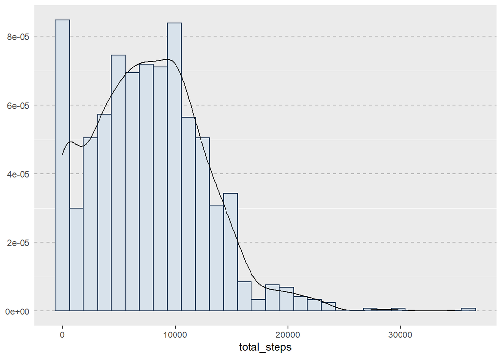

```r
steps_graph_with_outlier <- ggplot(daily_activity, aes(x=total_steps)) +
      geom_histogram(aes(y = ..density..), colour = "#1F3552", fill = "#D8E2EB") +
      geom_density() +
      theme_cleveland () +
      scale_y_continuous(labels = scientific)

steps_graph_with_outlier
```

```r
#cleaning the environment, dropping the obsolete dataframe
rm(steps_graph_with_outlier)
```

This is a normal looking curve with a positive skew and extreme outliers after 25,000 steps Now, I Filtered out days where no activity is recorded and outliers and rerun save the results, I will remove the outliers and create a new graph.

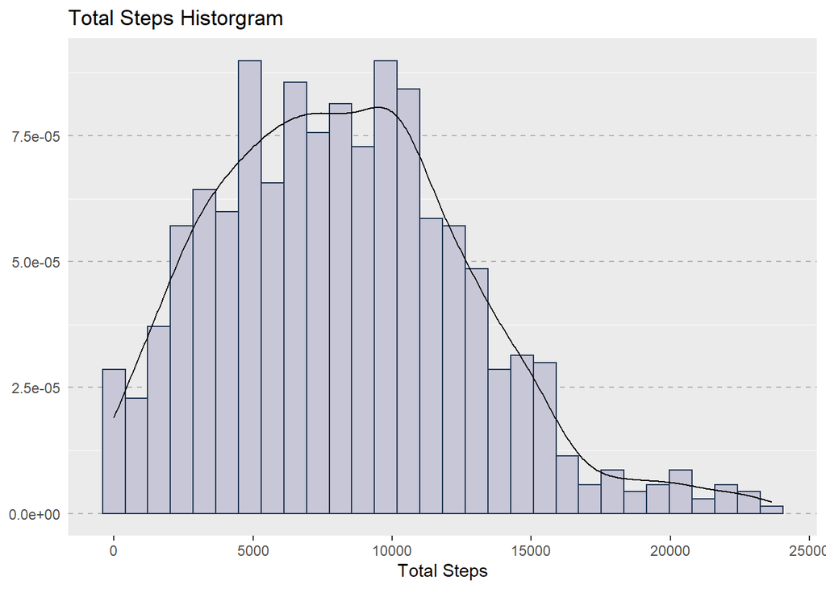

```r
#Removing outliers

daily_activity <- daily_activity[(daily_activity$total_steps>0) & (daily_activity$total_steps < 25000) ,]

#steps_graph: Steps Analysis  after removing outliers
# Produce new histogram

steps_graph_without_outliers <-
  ggplot(daily_activity, aes(total_steps,)) +
  geom_histogram(aes(y = ..density..), colour = "#1F3552", fill = "#c8c7d7") +
  geom_density(alpha = 0.3) +
  ggtitle("Historgram of Total Steps") +
  theme_cleveland () +
  labs(title = "Total Steps Historgram",
       x = "Total Steps", y = "Density")

steps_graph_without_outliers
```

```r
#cleaning the environment, dropping the obsolete dataframe
rm(steps_graph_without_outliers)
```

There is still a skew, but we have minimized extreme bias.

##### **Running Descriptive Analysis**

Here, I am running a descriptive statistics to familiarize myself with the data.

```r
monthly_user_activity <-
      daily_activity  %>%
      group_by(id) %>%
      summarise(
        record_count = n(),
        sum_steps_monthly = sum(total_steps),
        min_steps_monthly = min(total_steps),
        max_steps_monthly = max(total_steps),
        median_steps_monthly = median(total_steps),
        median_steps_daily = median(total_steps)/n(),
        avg_steps_monthly = mean(total_steps),
        std_steps_monthly = sd(total_steps)
      )

monthly_user_activity
```

```
## # A tibble: 33 × 9
##            id record_c…¹ sum_s…² min_s…³ max_s…⁴ media…⁵ media…⁶ avg_s…⁷ std_s…⁸
##         <dbl>      <int>   <dbl>   <dbl>   <dbl>   <dbl>   <dbl>   <dbl>   <dbl>
##  1 1503960366         30  375619    9705   18134  12438    415.   12521.   2099.
##  2 1624580081         30  142042    1510   10536   3726.   124.    4735.   2610.
##  3 1644430081         30  218489    1223   18213   6684.   223.    7283.   4325.
##  4 1844505072         21   79982       4    8054   4014    191.    3809.   2475.
##  5 1927972279         17   28400     149    3790   1675     98.5   1671.   1177.
##  6 2022484408         31  352490    3292   18387  11548    373.   11371.   2807.
##  7 2026352035         31  172573     254   12357   5528    178.    5567.   2978.
##  8 2320127002         31  146223     772   10725   5057    163.    4717.   2255.
##  9 2347167796         18  171354      42   22244   9781    543.    9520.   4682.
## 10 2873212765         31  234229    2524    9685   7762    250.    7556.   1514.
## # … with 23 more rows, and abbreviated variable names ¹record_count,
## #   ²sum_steps_monthly, ³min_steps_monthly, ⁴max_steps_monthly,
## #   ⁵median_steps_monthly, ⁶median_steps_daily, ⁷avg_steps_monthly,
## #   ⁸std_steps_monthly
```

Some individuals have extremely low engagement, which may skew analyses. I’ll group people according to their levels of engagement in order to analyze it further.

Now for detailed analysis, I’m distributing the participants into four groups (Never, Low, Moderate, and High) on how often they track their health. It will help us to analyze the Weight data,Steps count and Sleep activities for each user. The users with more then 20 days records are categorized as **High**, the ones with activity records between 10 and 20 days are assigned the **Moderate** category, users with records less then 10 days are categorized as **Low** and for those who have NO records for any activity are categorized as **Never**.

```r
daily_steps_records <-
        daily_activity %>%
        count(id) %>%
        mutate(steps_groups = case_when(
          n <= 10 ~ "Low",
          n <= 20 ~ "Moderate",
          n <= 31 ~ "High"
        )
           )


      #counting how many nights each participant recorded their sleep and also grouping them
       #based on frequency of recording
      sleep_records <-
        sleep_data %>%
        count(id) %>%
        mutate(sleep_groups = case_when(
          n <= 10 ~ "Low",
          n <= 20 ~ "Moderate",
          n <= 31 ~ "High"
        )
        )


       #doing the same for weight
      weight_records <-
        weight_data %>%
        count(id) %>%
        mutate(weight_groups = case_when(
          n <= 10 ~ "Low",
          n <= 20 ~ "Moderate",
          n <= 31 ~ "High"
        )
        )



#full join with sleep
daily_steps_records <-
  daily_steps_records       %>%
  full_join(sleep_records, by="id")

# full join with weight
daily_steps_records <-
  daily_steps_records       %>%
  full_join(weight_records, by="id")

daily_steps_records <-
  daily_steps_records %>%
  replace_na(list(sleep_records = 0, weight_records = 0, sleep_groups = "Never", weight_groups = "Never"))


#renaming the column 2 of the data set
colnames(daily_steps_records)[2] <- 'total_count'


#Dropping extra columns created while merge
daily_steps_records <- daily_steps_records[ -c(4,6) ]



  #categorizing overall device usage by the participants
    sleep_groups_percentage <-   daily_steps_records %>% group_by(sleep_groups) %>% summarise(Percentage=n()/nrow(.)) #calculating the % of High,Low,Med for users
      colnames(sleep_groups_percentage)[1] <- 'group'

    steps_groups_percentage <-   daily_steps_records %>% group_by(steps_groups) %>% summarise(Percentage=n()/nrow(.))  #calculating the % of High,Low,Med for users
          colnames(steps_groups_percentage)[1] <- 'group'

    weight_groups_percentage <-  daily_steps_records %>% group_by(weight_groups) %>% summarise(Percentage=n()/nrow(.))  #calculating the % of High,Low,Med for users
          colnames(weight_groups_percentage)[1] <- 'group'

#joining all activities in a single dataframe.
device_user_percentage <-
   steps_groups_percentage    %>%
  full_join(sleep_groups_percentage, by="group")


device_user_percentage <-
  device_user_percentage       %>%
  full_join(weight_groups_percentage, by="group")

colnames(device_user_percentage) <- c('Recording_Frequency','steps_Percent','sleep_Percent', 'weight_percent') #renaming the dataframe columns
device_user_percentage[is.na(device_user_percentage)] = 0 #replacing all NAs with 0
device_user_percentage[2:4] <- sapply(device_user_percentage[2:4], function(x) percent(x, accuracy=2)) #converting decimal values to % form.


#cleaning the environment, dropping all the obsolete dataframes
rm(sleep_records, weight_records,sleep_groups_percentage,steps_groups_percentage,weight_groups_percentage)


daily_steps_records
```

```
## # A tibble: 33 × 5
##            id total_count steps_groups sleep_groups weight_groups
##         <dbl>       <int> <chr>        <chr>        <chr>
##  1 1503960366          30 High         High         Low
##  2 1624580081          30 High         Never        Never
##  3 1644430081          30 High         Low          Never
##  4 1844505072          21 High         Low          Never
##  5 1927972279          17 Moderate     Low          Low
##  6 2022484408          31 High         Never        Never
##  7 2026352035          31 High         High         Never
##  8 2320127002          31 High         Low          Never
##  9 2347167796          18 Moderate     Moderate     Never
## 10 2873212765          31 High         Never        Low
## # … with 23 more rows
```

##### **Activity wise Device Engagement - Alluvial plot**

In order to determine which features of the devices are most and least used, we now look for the device conversion rate or engagement rate. This will make it easier for us to comprehend how user numbers increase/decrease as users switch between different activities

```r
#Transforming the recording frequency data frame into a long format to make the building of the alluvial plot easier.

actvities_graph_data  <- daily_steps_records[c("id", "steps_groups", "sleep_groups", "weight_groups")] %>%
  pivot_longer(!id )



actvties_analysis_graph  <-
    ggplot(actvities_graph_data, aes(x = name, stratum = value, alluvium = id, fill = value, label = value)) +
    scale_x_discrete(limits = c("steps_groups", "sleep_groups", "weight_groups"), expand = c(.1, .1))+
    geom_flow() +
    geom_stratum(alpha = .5) +
    geom_text(stat = "stratum", size = 3) +
    labs(title = "Device Usage for Each actvity", x = " ", y = "Number of users") +
   scale_y_reverse()+
    scale_fill_brewer(type = "qual", palette = "Set2") +
    theme(legend.position = "none",
          panel.background = element_blank(),
          axis.text.x = element_text(size = 14),
          axis.text.y = element_text(size = 10),
          plot.title = element_text(size=18, hjust = 0.5),
          axis.title.y = element_text(size = 14))




device_user_percentage
```

```
## # A tibble: 4 × 4
##   Recording_Frequency steps_Percent sleep_Percent weight_percent
##   <chr>               <chr>         <chr>         <chr>
## 1 High                76%           36%           6%
## 2 Low                 4%            28%           18%
## 3 Moderate            22%           10%           0%
## 4 Never               0%            28%           76%
```

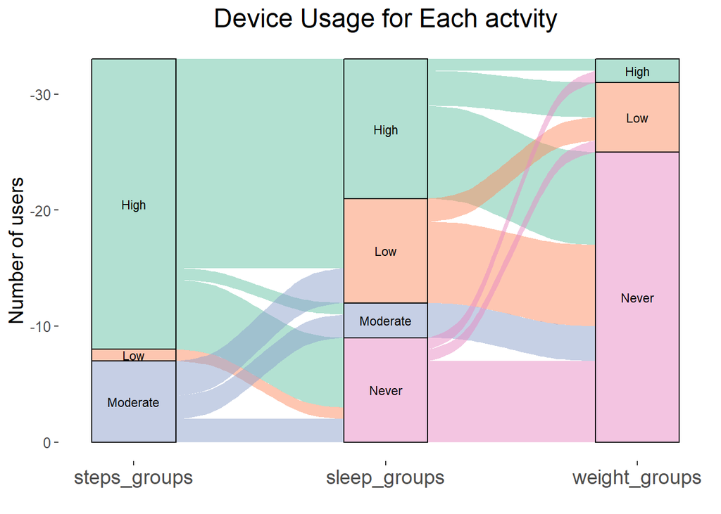

```r
actvties_analysis_graph
```

```r
#cleaning the environment, dropping all the obsolete dataframes
rm(actvities_graph_data, device_user_percentage, actvties_analysis_graph)
```

**Key Insights:**

- **75%+** users recorded their daily steps for more then 20days, this reduces to **36%** when it comes to sleep monitoring and its further reduced to **6%** when it comes to recording the weights.
- Another trend which can be visualized here is of **Moderate Users**,(those who recorded more then 10day and less then 20days), it keep decreasing i.e. **22%, 10%, & 0%** for Steps group, Sleep Group and weight group respectively.
- The data shares the trend that there is a sharp growth in *Never Recorder’s* chunk, as its **0%** for Daily steps recorders, its **28%** and **76%** for Sleep and Weight recorders respectively.

##### **Daily Steps Records Vs Device Usage - Scatter plot**

```r
#filtering data for outliers
filter_records <- filter(daily_steps_records, total_count < 10)


#removed id "4057192912" because they only recorded 3 out of 31 days

  daily_steps_records <- subset(daily_steps_records, id!= 4057192912)

#verifying the data accuracy
  filter(daily_steps_records, (daily_steps_records$id == "4057192912"))
```

```
## # A tibble: 0 × 5
## # … with 5 variables: id <dbl>, total_count <int>, steps_groups <chr>,
## #   sleep_groups <chr>, weight_groups <chr>
```

```r
  #Recording Frequency vs Monthly Steps
device_engagment <- ggplot(data=monthly_user_activity, aes(x = record_count, y = avg_steps_monthly))+
                    geom_point() +
                    geom_smooth(method = lm) +
                    theme_minimal() +
                    labs(title = "Recording Frequency vs Monthly Steps",
                         x = "Number of Days Recorded", y = "Average Steps Per Participant") +
                    theme(plot.title = element_text(size = 12, hjust = 0.5),
                          axis.title.x = element_text(size = 10),
                          axis.title.y = element_text(size = 10))

daily_steps_records
```

```
## # A tibble: 32 × 5
##            id total_count steps_groups sleep_groups weight_groups
##         <dbl>       <int> <chr>        <chr>        <chr>
##  1 1503960366          30 High         High         Low
##  2 1624580081          30 High         Never        Never
##  3 1644430081          30 High         Low          Never
##  4 1844505072          21 High         Low          Never
##  5 1927972279          17 Moderate     Low          Low
##  6 2022484408          31 High         Never        Never
##  7 2026352035          31 High         High         Never
##  8 2320127002          31 High         Low          Never
##  9 2347167796          18 Moderate     Moderate     Never
## 10 2873212765          31 High         Never        Low
## # … with 22 more rows
```

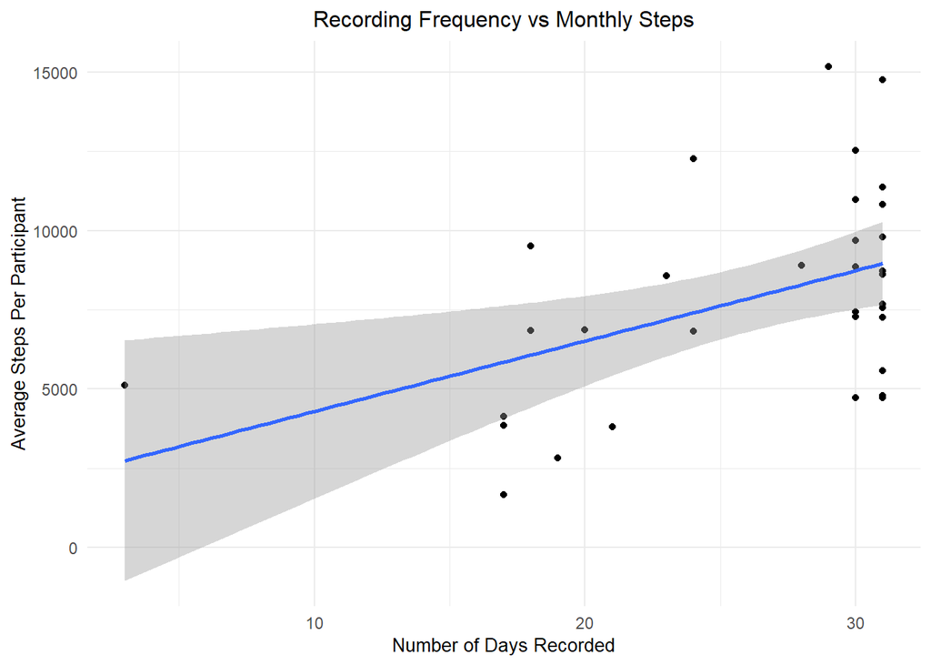

```r
device_engagment
```

```r
#cleaning the environment, dropping all the obsolete dataframes
rm(filter_records,device_engagment, daily_steps_records )
```

There is just one user with less than 10days records, renaming users have recorded the steps for more than 10days. Its clear in above graph that there is a positive correlation between daily steps and days recorded, so we can say that the more someone records their health data, we see a higher average daily steps.

##### **Trends in Time**

Here, I’ll be looking for answers of following questions. - Is there a trend in time? - Is a particular time of the day or night when participants use the device more? - who are the device users ? User social profile if possible. - Most active hours ?

```r
#Most Active Hours

steps_perhour$hours <- format(as.POSIXct(steps_perhour$hours), format = "%H:%M")  #remove the seconds and just have hours and minutes

 most_active_hours <- steps_perhour %>%
   group_by(hours) %>%
   summarize(avg_steps_hourly = mean(step_total)) %>% #find average steps for each hour
   ggplot(aes(hours, avg_steps_hourly, group = 1)) +
   geom_line(color = "#900C3F") +
   ggtitle("Average Steps Per Hour") +
   theme_minimal() +
   theme(axis.text.x = element_text(angle = 90, vjust = 0.5, hjust=1),
         text = element_text(size = 8)) +
   xlab("Hour of the Day") + ylab("Average Step Count") +
   annotate("rect", xmin = "11:00", xmax = "15:00",
            ymin = 0, ymax = 700, alpha = .1) +
   annotate("rect", xmin = "17:00", xmax = "20:00",
            ymin = 0, ymax = 700, alpha = .1) +
   annotate("rect",  xmin = "07:00", xmax = "10:00",
            ymin = 0, ymax = 700, alpha = .1) +
      annotate("text", x = "13:00", y = 650,
            label = "Afternoon", hjust = "center", size = 3) +
   annotate("text", x = 19.5, y = 650,
            label = "Evening", hjust = "center", size = 3) +
    annotate("text", x = 9.5, y = 650,
          label = "Morning", hjust = "center", size = 3)



 steps_perhour
```

```
## # A tibble: 22,099 × 4
##            id activity_hour hours step_total
##         <dbl> <date>        <chr>      <dbl>
##  1 1503960366 2016-04-12    00:00        373
##  2 1503960366 2016-04-12    01:00        160
##  3 1503960366 2016-04-12    02:00        151
##  4 1503960366 2016-04-12    03:00          0
##  5 1503960366 2016-04-12    04:00          0
##  6 1503960366 2016-04-12    05:00          0
##  7 1503960366 2016-04-12    06:00          0
##  8 1503960366 2016-04-12    07:00          0
##  9 1503960366 2016-04-12    08:00        250
## 10 1503960366 2016-04-12    09:00       1864
## # … with 22,089 more rows
```

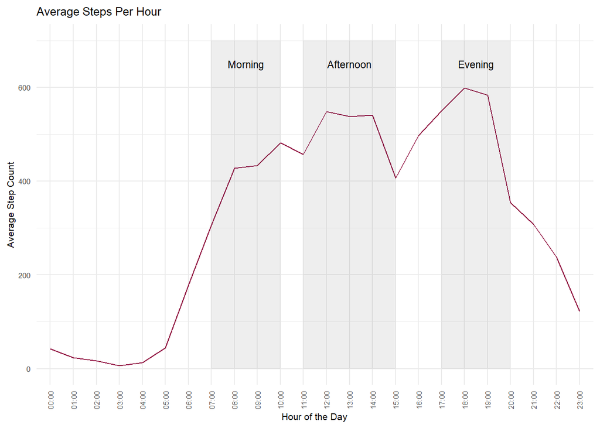

```r
 most_active_hours
```

The above time trends show us that mostly there are a 3 type of active users, the ones who exercise during morning time, some do it in afternoon while there is peak in evening time as well. To analyze it further we must break the data in quartiles and investigate.

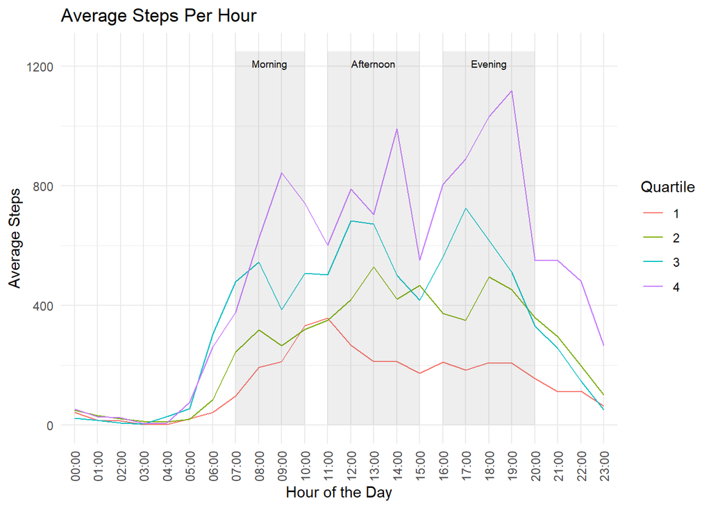

```r
 monthly_user_activity$sum_quartile <- as.factor(ntile(monthly_user_activity$sum_steps_monthly, 4))

 steps_perhour <- inner_join(steps_perhour, monthly_user_activity[ , c("id", "sum_quartile")], by = "id")



 most_active_hours <-  steps_perhour %>%
   group_by(sum_quartile, hours) %>%
   summarize(avg_steps_hourly = mean(step_total)) %>% #find average steps for each hour
   ggplot(aes(hours, avg_steps_hourly, group = sum_quartile, color = sum_quartile)) +
   geom_line() +
   ggtitle("Average Steps Per Hour") +
   theme_minimal() +
   theme(axis.text.x = element_text(angle = 90, vjust = 0.5, hjust=1))+
   xlab("Hour of the Day") + ylab("Average Steps") +
   labs(color = "Quartile") +
   annotate("rect", xmin = "16:00", xmax = "20:00",
            ymin = 0, ymax = 1250, alpha = .1) +
   annotate("rect", xmin = "11:00", xmax = "15:00",
            ymin = 0, ymax = 1250, alpha = .1) +
   annotate("rect", xmin = "07:00", xmax = "10:00",
            ymin = 0, ymax = 1250, alpha = .1) +
   annotate("text", x = "18:00", y = 1210,
            label = "Evening", hjust = "center", size = 2.5) +
   annotate("text", x = "13:00", y = 1210,
            label = "Afternoon", hjust = "center", size = 2.5) +
   annotate("text", x = 9.5, y = 1210,
            label = "Morning", hjust = "center", size = 2.5)
 most_active_hours
```

```r
 #cleaning the environment, dropping the obsolete dataframe
   rm(most_active_hours)
```

**Key Insights:** - We see that the top two most active groups( 3 and 4) of this sample peaks three times: around morning, afternoon and evening, it seems these two groups represent the 9-5 office working persons. Quartile 4 , have a small peak around 9:00am, and second peak around 2:00pm while its highest/busiest peak hour is 7:00pm. Quartile 3, its peak is around 8:00am, second peakis around 12:00pm, while its busiest hour is around 5:00pm - Quartile 2, one of the least active group has a small peak in the morning time, but it can be observed that the afternoon and evening peaks as stronger and clearer. - Quartile 1, the least active of the sample seems to have one small peak in the late morning.

##### **Sleep Trends**

Lets look at the relationship of high intense activity time and sleep. We need look for any trends that those who are more active throughout the day sleep more than those who are less active? Could the duration of high activity have an impact on this relationship?

I wouldn’t be able to determine the precise difference between those two variables (intense workout and bedtime) because I don’t know what time the person went to sleep. However, I can use the hour of maximum steps as a color code to indicate how much time they slept that day in relation to the number of steps they took.

```r
  colnames(sleep_data)[2] <- 'date' #renaming col2 from sleep_data to date

 #calculate hour of max steps taken
 max_steps_perhour <- steps_perhour %>%
   group_by(id, activity_hour) %>%
   summarise(max_step_perhour = hours[which.max(step_total)])
```

[output not shown]

[figure not shown]

```r
 #change to integer so it is accepted in the legend
 max_steps_perhour$max_step_perhour <- as.numeric(gsub("(.*?)\\s|\\:00*", "", max_steps_perhour$max_step_perhour))

  #add total steps per day for each night of sleep
 sleep_data <- inner_join(sleep_data, daily_activity[ , c("id", "activity_date", "total_steps")], by = c("id" = "id", "date" = "activity_date"))

 sleep_data <- inner_join(sleep_data, max_steps_perhour, by = c("id" = "id", "date" = "activity_hour"))


 sleep_vs_Steps_graph <- sleep_data %>%
   ggplot(aes(x = total_steps, y = total_minutes_asleep, color = max_step_perhour)) +
   geom_point() +
   scale_color_gradientn(colours = rainbow(5),
                         breaks = c(seq(0, 20, 5)),
                         labels = c(sprintf(
                           "%s:00",
                           seq(0, 20, 5)
                         ))) +
   geom_smooth(method = lm, alpha = 0.3) +
   theme_linedraw() +
   labs(title = "Sleep vs Steps (per day)",
        x = "Minutes Asleep", y = "Steps",
        color = "Hour of Max Step") +
   theme(plot.title = element_text(size = 12, hjust = 0.5),
         axis.title.x = element_text(size = 10),
         axis.title.y = element_text(size = 10),
         legend.key.size = unit(5, 'mm'),
         legend.title = element_text(size = 8),
         legend.text = element_text(size = 6))

 sleep_vs_Steps_graph
```

```r
  #cleaning the environment, dropping the obsolete dataframe
   rm(sleep_vs_Steps_graph, max_steps_perhour)
```

Here, Sleep and steps is compared for each participant, above scatter plot shows the comparison between total minutes asleep and total steps taken. In order to estimate whether a participant’s most intense workout had an impact on their ability to sleep, I colored the hour in which they took the most steps. Surprisingly, a negative relationship between sleep and daily steps is revealed.This sample shows that as a person walks more, his/her sleep gets reduced.

Now, we have to look for any trends in days, do any particular day(i.e. weekends) effects the activities or users have the same routine throughout the week.

```r
 sleep_data$difference_bedtime <- sleep_data$total_time_in_bed -sleep_data$total_minutes_asleep

 mean(sleep_data$total_time_in_bed - sleep_data$total_minutes_asleep)
```

```
## [1] 39.44963
```

```r
 #prepping the data for histogram (long format)
 bedtime_histogram <-
   inner_join(sleep_data[c("id", "total_minutes_asleep", "total_time_in_bed")], monthly_user_activity[c("id", "sum_quartile")], by = "id") %>%
   pivot_longer(!c(id, sum_quartile))

 #summarizing data for labels
 mean_difference <- sleep_data %>%
   summarise(average_difference = round(mean(difference_bedtime), 2),
             data_count = n(),
             group_size = length(unique(id)))


    bedtime_histogram
```

```
## # A tibble: 814 × 4
##            id sum_quartile name                 value
##         <dbl> <fct>        <chr>                <dbl>
##  1 1503960366 4            total_minutes_asleep   327
##  2 1503960366 4            total_time_in_bed      346
##  3 1503960366 4            total_minutes_asleep   384
##  4 1503960366 4            total_time_in_bed      407
##  5 1503960366 4            total_minutes_asleep   412
##  6 1503960366 4            total_time_in_bed      442
##  7 1503960366 4            total_minutes_asleep   340
##  8 1503960366 4            total_time_in_bed      367
##  9 1503960366 4            total_minutes_asleep   700
## 10 1503960366 4            total_time_in_bed      712
## # … with 804 more rows
```

```r
    mean_difference
```

```
## # A tibble: 1 × 3
##   average_difference data_count group_size
##                <dbl>      <int>      <int>
## 1               39.4        407         24
```

```r
     daygraph <- daily_activity
 daygraph <- daygraph [ -c(1,2,5,6,7,8,9,10,11,12,13,14,15,16) ]

   daygraph <- daygraph %>%
     group_by(day) %>%
     summarise(
     avg = mean(total_steps))


 #cleaning the environment, dropping the obsolete dataframe
 rm ( mean_difference)
```

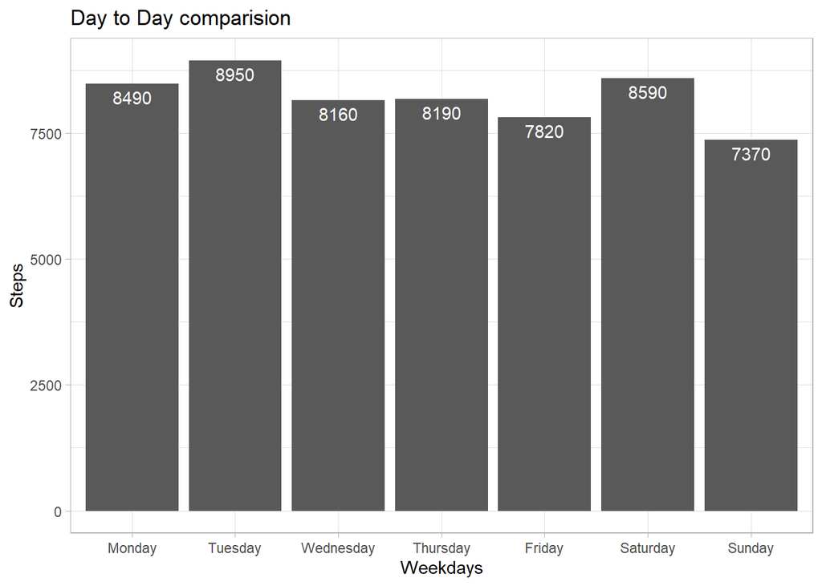

```r
ggplot(daygraph, aes(x= factor(day, levels = c("Monday", "Tuesday", "Wednesday", "Thursday", "Friday", "Saturday", "Sunday")), y= avg)) +
  geom_bar(position="dodge", stat="identity")+
  theme_light()+
    labs(title = "Day to Day comparision",
       x = "Weekdays", y = "Steps",
       color = "Average Steps")+
  geom_text(aes(label = signif(avg, digits = 3)),  vjust = 1.5, colour = "white")
```

The above bar graphs show that there is no pattern that suggests a rise or fall in user engagement, and user activities are unaffected by weekends. There is nothing more that can be analyzed from the sample of data provided; in order to conduct a more thorough analysis, more data would be required. According to current data Tuesdays and Saturdays are the busiest days.

**Sleep delays: Time in bed vs Time asleep** Now we need to analyze how much time is taken by a users from going to bed to going to sleep. we can analyze it by using the sleep dataframe. The average sleep delay is about 40 minutes. lets visualize and analyze it..

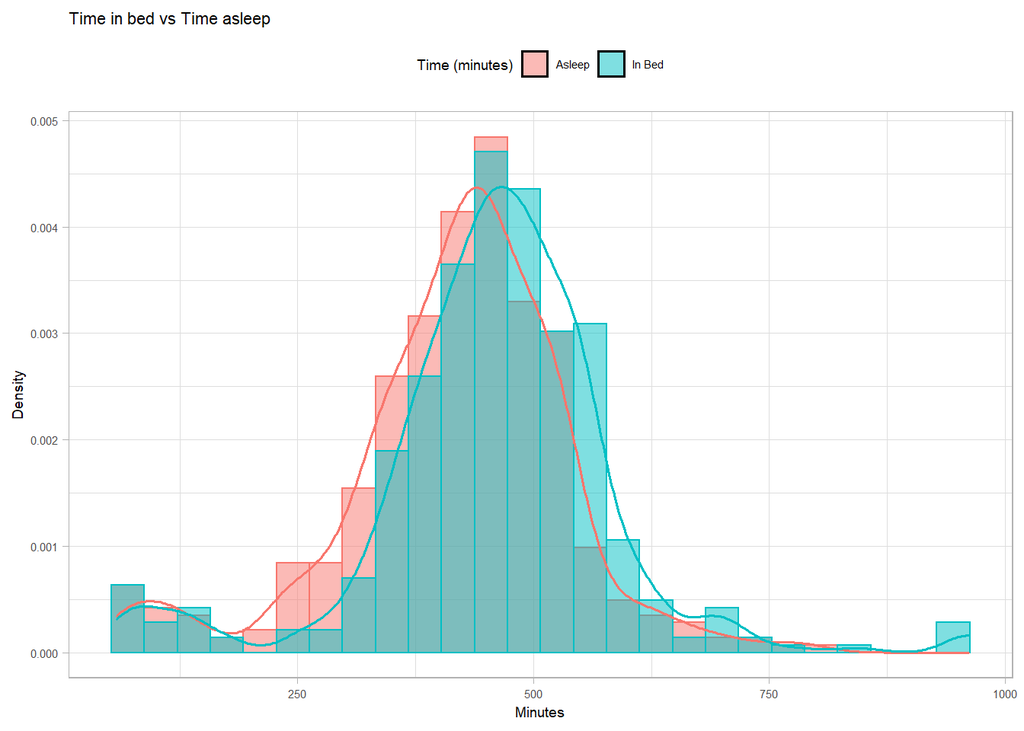

```r
#Density Histogram of Time Asleep and In Bed

 bedtime_histogram %>%
   ggplot(aes(x = value, color = name, fill = name)) +
   geom_histogram(aes(y = ..density..),  position = "identity", alpha = .5, binwidth = 35) +
   guides(col = FALSE) +
   geom_density(alpha = 0, lwd = .6) +
   theme_light() +
     theme(legend.position = "top",
         legend.key.size = unit(5, 'mm'),
         text = element_text(size = 7))+
   labs(title = "Time in bed vs Time asleep ",
        x = "Minutes", y = "Density") +
   scale_fill_discrete(name = "Time (minutes)", labels = c("Asleep", "In Bed"))
```

## Step 6: Act

#### **Key Insight:**

**Time Trends** - Most Active days are Tuesdays and Saturdays and least active days are Friday & Sundays. - Most of the users use the device for steps recording between following hours; 07:00-8:00am, 12:00pm-2:00pm and 5:00pm-7:00pm.

**Sleep Trends** - People in this sample slept for shorter periods of time as they logged more steps. - The average sleep delay is about 40 minutes

#### **Recommendations:**

**Competitions** - Create a regional leader board (like Ludo star) with users’ weekly/monthly step counts compared to one another for competitions. The top 3 users can receive gifts or coupons for discounts on future wearable purchases at the end of each term.

**Notifications** - Provide notifications to the user regrading daily/weekly activity goal. In order to aid users in getting ready for bed, notifications could also be sent an hour beforehand.

**Referrals** - Include a referral program so that existing wearable users can get progressively bigger discounts on goods or future wearable purchases based on how many of their referrals buy a wearable.

**User Engagement Feature** - develop some feature which will encourage use of the product to further your fitness goals i.e.Point system or Goals/streaks.

To conclude, I wanted to help Bellabeat better understand its customer base and provide helpful advice so that customers can reach their fitness objectives. Following my suggestions will significantly increase customer engagement with our products and Bellabeat’s long-term success.